# Risk Factor Analysis

## Outcome Variable

**Outcome Variable:** stunted

## Predictor Variables

**Intervention Variable:** hhwealth_quart

**Adjustment Set:**

- arm
- sex
- W_mage
- meducyrs
- feducyrs
- W_gagebrth
- W_birthwt
- W_birthlen
- W_nchldlt5
- W_parity
- delta_W_mage
- delta_meducyrs
- delta_feducyrs
- delta_W_gagebrth
- delta_W_birthwt
- delta_W_birthlen
- delta_W_nchldlt5
- delta_W_parity

## Stratifying Variables

The analysis was stratified on these variable(s):

- agecat
- studyid
- country

## Data Summary

| agecat | studyid | country | hhwealth_quart | stunted | n_cell | n |
| --- | --- | --- | --- | --- | --- | --- |
| Birth | ki0047075b-MAL-ED | BANGLADESH | Wealth Q4 | 0 | 23 | 82 |
| Birth | ki0047075b-MAL-ED | BANGLADESH | Wealth Q4 | 1 | 3 | 82 |
| Birth | ki0047075b-MAL-ED | BANGLADESH | Wealth Q1 | 0 | 3 | 82 |
| Birth | ki0047075b-MAL-ED | BANGLADESH | Wealth Q1 | 1 | 1 | 82 |
| Birth | ki0047075b-MAL-ED | BANGLADESH | Wealth Q2 | 0 | 13 | 82 |
| Birth | ki0047075b-MAL-ED | BANGLADESH | Wealth Q2 | 1 | 2 | 82 |
| Birth | ki0047075b-MAL-ED | BANGLADESH | Wealth Q3 | 0 | 27 | 82 |
| Birth | ki0047075b-MAL-ED | BANGLADESH | Wealth Q3 | 1 | 10 | 82 |
| 6 months | ki0047075b-MAL-ED | BANGLADESH | Wealth Q4 | 0 | 24 | 81 |
| 6 months | ki0047075b-MAL-ED | BANGLADESH | Wealth Q4 | 1 | 2 | 81 |
| 6 months | ki0047075b-MAL-ED | BANGLADESH | Wealth Q1 | 0 | 3 | 81 |
| 6 months | ki0047075b-MAL-ED | BANGLADESH | Wealth Q1 | 1 | 1 | 81 |
| 6 months | ki0047075b-MAL-ED | BANGLADESH | Wealth Q2 | 0 | 11 | 81 |
| 6 months | ki0047075b-MAL-ED | BANGLADESH | Wealth Q2 | 1 | 4 | 81 |
| 6 months | ki0047075b-MAL-ED | BANGLADESH | Wealth Q3 | 0 | 27 | 81 |
| 6 months | ki0047075b-MAL-ED | BANGLADESH | Wealth Q3 | 1 | 9 | 81 |
| 24 months | ki0047075b-MAL-ED | BANGLADESH | Wealth Q4 | 0 | 15 | 77 |
| 24 months | ki0047075b-MAL-ED | BANGLADESH | Wealth Q4 | 1 | 11 | 77 |
| 24 months | ki0047075b-MAL-ED | BANGLADESH | Wealth Q1 | 0 | 1 | 77 |
| 24 months | ki0047075b-MAL-ED | BANGLADESH | Wealth Q1 | 1 | 3 | 77 |
| 24 months | ki0047075b-MAL-ED | BANGLADESH | Wealth Q2 | 0 | 8 | 77 |
| 24 months | ki0047075b-MAL-ED | BANGLADESH | Wealth Q2 | 1 | 7 | 77 |
| 24 months | ki0047075b-MAL-ED | BANGLADESH | Wealth Q3 | 0 | 16 | 77 |
| 24 months | ki0047075b-MAL-ED | BANGLADESH | Wealth Q3 | 1 | 16 | 77 |
| Birth | ki0047075b-MAL-ED | BRAZIL | Wealth Q4 | 0 | 1 | 3 |
| Birth | ki0047075b-MAL-ED | BRAZIL | Wealth Q4 | 1 | 1 | 3 |
| Birth | ki0047075b-MAL-ED | BRAZIL | Wealth Q2 | 0 | 0 | 3 |
| Birth | ki0047075b-MAL-ED | BRAZIL | Wealth Q2 | 1 | 1 | 3 |
| 6 months | ki0047075b-MAL-ED | BRAZIL | Wealth Q4 | 0 | 2 | 3 |
| 6 months | ki0047075b-MAL-ED | BRAZIL | Wealth Q2 | 0 | 1 | 3 |

[output cut: 334 more lines]

The following strata were considered:

- agecat: 24 months, studyid: ki0047075b-MAL-ED, country: BANGLADESH
- agecat: 24 months, studyid: ki0047075b-MAL-ED, country: BRAZIL
- agecat: 24 months, studyid: ki0047075b-MAL-ED, country: INDIA
- agecat: 24 months, studyid: ki0047075b-MAL-ED, country: NEPAL
- agecat: 24 months, studyid: ki0047075b-MAL-ED, country: PERU
- agecat: 24 months, studyid: ki0047075b-MAL-ED, country: SOUTH AFRICA
- agecat: 24 months, studyid: ki0047075b-MAL-ED, country: TANZANIA, UNITED REPUBLIC OF
- agecat: 24 months, studyid: ki1000108-CMC-V-BCS-2002, country: INDIA
- agecat: 24 months, studyid: ki1000108-IRC, country: INDIA
- agecat: 24 months, studyid: ki1017093b-PROVIDE, country: BANGLADESH
- agecat: 24 months, studyid: ki1066203-TanzaniaChild2, country: TANZANIA, UNITED REPUBLIC OF
- agecat: 24 months, studyid: ki1113344-GMS-Nepal, country: NEPAL
- agecat: 24 months, studyid: ki1114097-CONTENT, country: PERU
- agecat: 24 months, studyid: ki1135781-COHORTS, country: GUATEMALA
- agecat: 24 months, studyid: ki1135781-COHORTS, country: PHILIPPINES
- agecat: 24 months, studyid: ki1148112-LCNI-5, country: MALAWI
- agecat: 24 months, studyid: kiGH5241-JiVitA-3, country: BANGLADESH
- agecat: 24 months, studyid: kiGH5241-JiVitA-4, country: BANGLADESH
- agecat: 6 months, studyid: ki0047075b-MAL-ED, country: BANGLADESH
- agecat: 6 months, studyid: ki0047075b-MAL-ED, country: BRAZIL
- agecat: 6 months, studyid: ki0047075b-MAL-ED, country: INDIA
- agecat: 6 months, studyid: ki0047075b-MAL-ED, country: NEPAL
- agecat: 6 months, studyid: ki0047075b-MAL-ED, country: PERU
- agecat: 6 months, studyid: ki0047075b-MAL-ED, country: SOUTH AFRICA
- agecat: 6 months, studyid: ki0047075b-MAL-ED, country: TANZANIA, UNITED REPUBLIC OF
- agecat: 6 months, studyid: ki1000108-CMC-V-BCS-2002, country: INDIA
- agecat: 6 months, studyid: ki1000108-IRC, country: INDIA
- agecat: 6 months, studyid: ki1017093b-PROVIDE, country: BANGLADESH
- agecat: 6 months, studyid: ki1066203-TanzaniaChild2, country: TANZANIA, UNITED REPUBLIC OF
- agecat: 6 months, studyid: ki1113344-GMS-Nepal, country: NEPAL
- agecat: 6 months, studyid: ki1114097-CONTENT, country: PERU
- agecat: 6 months, studyid: ki1135781-COHORTS, country: GUATEMALA
- agecat: 6 months, studyid: ki1135781-COHORTS, country: PHILIPPINES
- agecat: 6 months, studyid: ki1148112-LCNI-5, country: MALAWI
- agecat: 6 months, studyid: kiGH5241-JiVitA-3, country: BANGLADESH
- agecat: 6 months, studyid: kiGH5241-JiVitA-4, country: BANGLADESH
- agecat: Birth, studyid: ki0047075b-MAL-ED, country: BANGLADESH
- agecat: Birth, studyid: ki0047075b-MAL-ED, country: BRAZIL
- agecat: Birth, studyid: ki0047075b-MAL-ED, country: INDIA
- agecat: Birth, studyid: ki0047075b-MAL-ED, country: NEPAL
- agecat: Birth, studyid: ki0047075b-MAL-ED, country: PERU
- agecat: Birth, studyid: ki0047075b-MAL-ED, country: SOUTH AFRICA
- agecat: Birth, studyid: ki0047075b-MAL-ED, country: TANZANIA, UNITED REPUBLIC OF
- agecat: Birth, studyid: ki1000108-CMC-V-BCS-2002, country: INDIA
- agecat: Birth, studyid: ki1000108-IRC, country: INDIA
- agecat: Birth, studyid: ki1114097-CONTENT, country: PERU
- agecat: Birth, studyid: ki1135781-COHORTS, country: GUATEMALA
- agecat: Birth, studyid: ki1135781-COHORTS, country: PHILIPPINES
- agecat: Birth, studyid: kiGH5241-JiVitA-3, country: BANGLADESH
- agecat: Birth, studyid: kiGH5241-JiVitA-4, country: BANGLADESH

### Dropped Strata

Some strata were dropped due to rare outcomes:

- agecat: Birth, studyid: ki0047075b-MAL-ED, country: BANGLADESH
- agecat: 6 months, studyid: ki0047075b-MAL-ED, country: BANGLADESH
- agecat: 24 months, studyid: ki0047075b-MAL-ED, country: BANGLADESH
- agecat: Birth, studyid: ki0047075b-MAL-ED, country: BRAZIL
- agecat: 6 months, studyid: ki0047075b-MAL-ED, country: BRAZIL
- agecat: 24 months, studyid: ki0047075b-MAL-ED, country: BRAZIL
- agecat: Birth, studyid: ki0047075b-MAL-ED, country: INDIA
- agecat: 6 months, studyid: ki0047075b-MAL-ED, country: INDIA
- agecat: 24 months, studyid: ki0047075b-MAL-ED, country: INDIA
- agecat: Birth, studyid: ki0047075b-MAL-ED, country: NEPAL
- agecat: 6 months, studyid: ki0047075b-MAL-ED, country: NEPAL
- agecat: 24 months, studyid: ki0047075b-MAL-ED, country: NEPAL
- agecat: Birth, studyid: ki0047075b-MAL-ED, country: PERU
- agecat: 6 months, studyid: ki0047075b-MAL-ED, country: PERU
- agecat: 24 months, studyid: ki0047075b-MAL-ED, country: PERU
- agecat: Birth, studyid: ki0047075b-MAL-ED, country: SOUTH AFRICA
- agecat: 6 months, studyid: ki0047075b-MAL-ED, country: SOUTH AFRICA
- agecat: 24 months, studyid: ki0047075b-MAL-ED, country: SOUTH AFRICA
- agecat: Birth, studyid: ki0047075b-MAL-ED, country: TANZANIA, UNITED REPUBLIC OF
- agecat: 6 months, studyid: ki0047075b-MAL-ED, country: TANZANIA, UNITED REPUBLIC OF
- agecat: 24 months, studyid: ki0047075b-MAL-ED, country: TANZANIA, UNITED REPUBLIC OF
- agecat: Birth, studyid: ki1000108-CMC-V-BCS-2002, country: INDIA
- agecat: 24 months, studyid: ki1066203-TanzaniaChild2, country: TANZANIA, UNITED REPUBLIC OF
- agecat: 6 months, studyid: ki1114097-CONTENT, country: PERU
- agecat: 24 months, studyid: ki1114097-CONTENT, country: PERU
- agecat: Birth, studyid: ki1114097-CONTENT, country: PERU

## Methods Detail

We’re interested in the causal parameters $E[Y_a]$ for all values of $a \in \mathcal{A}$. These parameters represent the mean outcome if, possibly contrary to fact, we intervened to set all units to have $A=a$. Under the randomization and positivity assumptions, these are identified by the statistical parameters $\psi_a=E_W[E_{Y|A,W}(Y|A=a,W)]$. In addition, we’re interested in the mean of $Y$, $E[Y]$ under no intervention (the observed mean). We will estimate these parameters by using SuperLearner to fit the relevant likelihood factors – $E_{Y|A,W}(Y|A=a,W)$ and $p(A=a|W)$, and then updating our likelihood fit using a joint TMLE.

For unadjusted analyses ($W=\{\}$), initial likelihoods were estimated using Lrnr_glm to estimate the simple $E(Y|A)$ and Lrnr_mean to estimate $p(A)$. For adjusted analyses, a small library containing Lrnr_glmnet, Lrnr_xgboost, and Lrnr_mean was used.

Having estimated these parameters, we will then use the delta method to estimate relative risks and attributable risks relative to a prespecified baseline level of $A$.

# Results Detail

## Results Plots

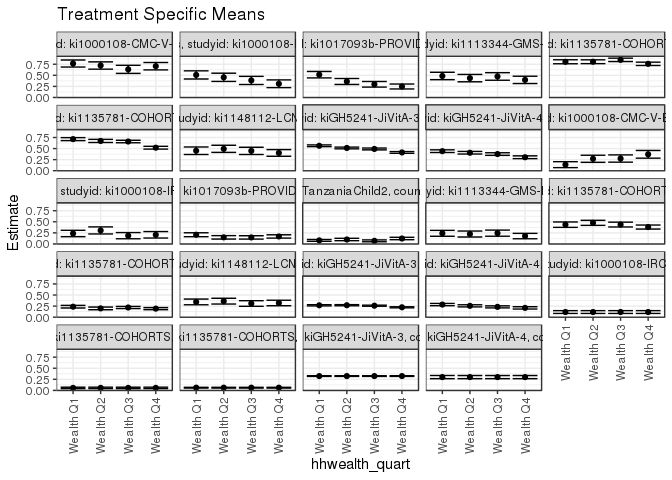

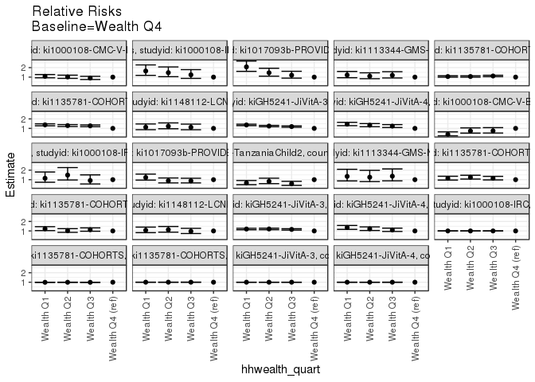

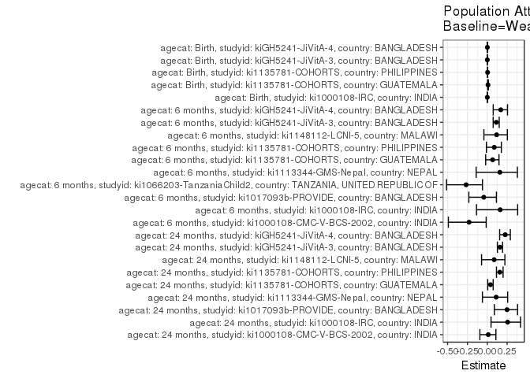

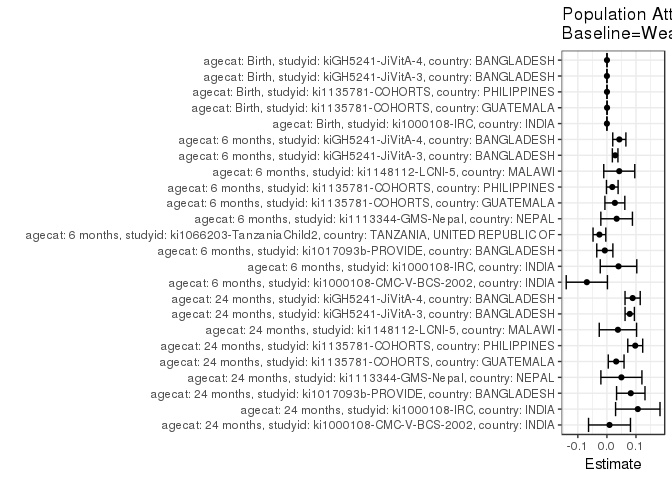

## Results Table

### Parameter: TSM

| agecat | studyid | country | intervention_level | baseline_level | estimate | ci_lower | ci_upper |
| --- | --- | --- | --- | --- | --- | --- | --- |
| Birth | ki1000108-IRC | INDIA | Wealth Q4 | NA | 0.1159738 | 0.0840732 | 0.1478745 |
| Birth | ki1000108-IRC | INDIA | Wealth Q1 | NA | 0.1159713 | 0.0840714 | 0.1478713 |
| Birth | ki1000108-IRC | INDIA | Wealth Q2 | NA | 0.1159757 | 0.0840745 | 0.1478768 |
| Birth | ki1000108-IRC | INDIA | Wealth Q3 | NA | 0.1159728 | 0.0840725 | 0.1478730 |
| Birth | ki1135781-COHORTS | GUATEMALA | Wealth Q4 | NA | 0.0570895 | 0.0412018 | 0.0729772 |
| Birth | ki1135781-COHORTS | GUATEMALA | Wealth Q1 | NA | 0.0564952 | 0.0407377 | 0.0722527 |
| Birth | ki1135781-COHORTS | GUATEMALA | Wealth Q2 | NA | 0.0567427 | 0.0409188 | 0.0725667 |
| Birth | ki1135781-COHORTS | GUATEMALA | Wealth Q3 | NA | 0.0564429 | 0.0407251 | 0.0721607 |
| Birth | ki1135781-COHORTS | PHILIPPINES | Wealth Q4 | NA | 0.0610927 | 0.0526044 | 0.0695810 |
| Birth | ki1135781-COHORTS | PHILIPPINES | Wealth Q1 | NA | 0.0611902 | 0.0526885 | 0.0696918 |
| Birth | ki1135781-COHORTS | PHILIPPINES | Wealth Q2 | NA | 0.0611808 | 0.0526801 | 0.0696814 |
| Birth | ki1135781-COHORTS | PHILIPPINES | Wealth Q3 | NA | 0.0612459 | 0.0527377 | 0.0697542 |
| Birth | kiGH5241-JiVitA-3 | BANGLADESH | Wealth Q4 | NA | 0.3232970 | 0.3156379 | 0.3309560 |
| Birth | kiGH5241-JiVitA-3 | BANGLADESH | Wealth Q1 | NA | 0.3233177 | 0.3156582 | 0.3309771 |
| Birth | kiGH5241-JiVitA-3 | BANGLADESH | Wealth Q2 | NA | 0.3233124 | 0.3156529 | 0.3309719 |
| Birth | kiGH5241-JiVitA-3 | BANGLADESH | Wealth Q3 | NA | 0.3233131 | 0.3156538 | 0.3309724 |
| Birth | kiGH5241-JiVitA-4 | BANGLADESH | Wealth Q4 | NA | 0.3002260 | 0.2646687 | 0.3357834 |
| Birth | kiGH5241-JiVitA-4 | BANGLADESH | Wealth Q1 | NA | 0.3002980 | 0.2647481 | 0.3358478 |
| Birth | kiGH5241-JiVitA-4 | BANGLADESH | Wealth Q2 | NA | 0.3001569 | 0.2646075 | 0.3357064 |
| Birth | kiGH5241-JiVitA-4 | BANGLADESH | Wealth Q3 | NA | 0.3002175 | 0.2646783 | 0.3357568 |
| 6 months | ki1000108-CMC-V-BCS-2002 | INDIA | Wealth Q4 | NA | 0.3698673 | 0.2830870 | 0.4566477 |
| 6 months | ki1000108-CMC-V-BCS-2002 | INDIA | Wealth Q1 | NA | 0.1359441 | 0.0689552 | 0.2029330 |
| 6 months | ki1000108-CMC-V-BCS-2002 | INDIA | Wealth Q2 | NA | 0.2691349 | 0.1886077 | 0.3496622 |
| 6 months | ki1000108-CMC-V-BCS-2002 | INDIA | Wealth Q3 | NA | 0.2746873 | 0.1924106 | 0.3569640 |
| 6 months | ki1000108-IRC | INDIA | Wealth Q4 | NA | 0.2057652 | 0.1328130 | 0.2787174 |
| 6 months | ki1000108-IRC | INDIA | Wealth Q1 | NA | 0.2361340 | 0.1640643 | 0.3082036 |
| 6 months | ki1000108-IRC | INDIA | Wealth Q2 | NA | 0.3047938 | 0.2251617 | 0.3844259 |
| 6 months | ki1000108-IRC | INDIA | Wealth Q3 | NA | 0.1866745 | 0.1164930 | 0.2568560 |
| 6 months | ki1017093b-PROVIDE | BANGLADESH | Wealth Q4 | NA | 0.1689700 | 0.1317670 | 0.2061731 |
| 6 months | ki1017093b-PROVIDE | BANGLADESH | Wealth Q1 | NA | 0.2076560 | 0.1632411 | 0.2520709 |

[output cut: 66 more lines]

### Parameter: E(Y)

| agecat | studyid | country | intervention_level | baseline_level | estimate | ci_lower | ci_upper |
| --- | --- | --- | --- | --- | --- | --- | --- |
| Birth | ki1000108-IRC | INDIA | NA | NA | 0.1159794 | 0.0840777 | 0.1478811 |
| Birth | ki1135781-COHORTS | GUATEMALA | NA | NA | 0.0575980 | 0.0416028 | 0.0735933 |
| Birth | ki1135781-COHORTS | PHILIPPINES | NA | NA | 0.0613316 | 0.0528136 | 0.0698496 |
| Birth | kiGH5241-JiVitA-3 | BANGLADESH | NA | NA | 0.3233133 | 0.3156536 | 0.3309730 |
| Birth | kiGH5241-JiVitA-4 | BANGLADESH | NA | NA | 0.3004866 | 0.2649179 | 0.3360553 |
| 6 months | ki1000108-CMC-V-BCS-2002 | INDIA | NA | NA | 0.3008130 | 0.2539566 | 0.3476694 |
| 6 months | ki1000108-IRC | INDIA | NA | NA | 0.2457002 | 0.2038248 | 0.2875757 |
| 6 months | ki1017093b-PROVIDE | BANGLADESH | NA | NA | 0.1617900 | 0.1318200 | 0.1917600 |
| 6 months | ki1066203-TanzaniaChild2 | TANZANIA, UNITED REPUBLIC OF | NA | NA | 0.0965347 | 0.0836528 | 0.1094165 |
| 6 months | ki1113344-GMS-Nepal | NEPAL | NA | NA | 0.2113677 | 0.1776128 | 0.2451225 |
| 6 months | ki1135781-COHORTS | GUATEMALA | NA | NA | 0.4086486 | 0.3769522 | 0.4403450 |
| 6 months | ki1135781-COHORTS | PHILIPPINES | NA | NA | 0.2112260 | 0.1958496 | 0.2266024 |
| 6 months | ki1148112-LCNI-5 | MALAWI | NA | NA | 0.3627451 | 0.3297365 | 0.3957537 |
| 6 months | kiGH5241-JiVitA-3 | BANGLADESH | NA | NA | 0.2513837 | 0.2432545 | 0.2595129 |
| 6 months | kiGH5241-JiVitA-4 | BANGLADESH | NA | NA | 0.2522280 | 0.2381653 | 0.2662906 |
| 24 months | ki1000108-CMC-V-BCS-2002 | INDIA | NA | NA | 0.7150538 | 0.6691221 | 0.7609854 |
| 24 months | ki1000108-IRC | INDIA | NA | NA | 0.4156479 | 0.3678270 | 0.4634689 |
| 24 months | ki1017093b-PROVIDE | BANGLADESH | NA | NA | 0.3298611 | 0.2914318 | 0.3682904 |
| 24 months | ki1113344-GMS-Nepal | NEPAL | NA | NA | 0.4468938 | 0.4032281 | 0.4905594 |
| 24 months | ki1135781-COHORTS | GUATEMALA | NA | NA | 0.7909441 | 0.7661948 | 0.8156934 |
| 24 months | ki1135781-COHORTS | PHILIPPINES | NA | NA | 0.6167689 | 0.5974942 | 0.6360437 |
| 24 months | ki1148112-LCNI-5 | MALAWI | NA | NA | 0.4390244 | 0.3983906 | 0.4796582 |
| 24 months | kiGH5241-JiVitA-3 | BANGLADESH | NA | NA | 0.4907805 | 0.4776507 | 0.5039102 |
| 24 months | kiGH5241-JiVitA-4 | BANGLADESH | NA | NA | 0.3922477 | 0.3752571 | 0.4092384 |

### Parameter: RR

| agecat | studyid | country | intervention_level | baseline_level | estimate | ci_lower | ci_upper |
| --- | --- | --- | --- | --- | --- | --- | --- |
| Birth | ki1000108-IRC | INDIA | Wealth Q4 | Wealth Q4 | 1.0000000 | 1.0000000 | 1.0000000 |
| Birth | ki1000108-IRC | INDIA | Wealth Q1 | Wealth Q4 | 0.9999784 | 0.9999444 | 1.0000123 |
| Birth | ki1000108-IRC | INDIA | Wealth Q2 | Wealth Q4 | 1.0000156 | 0.9999827 | 1.0000484 |
| Birth | ki1000108-IRC | INDIA | Wealth Q3 | Wealth Q4 | 0.9999906 | 0.9999579 | 1.0000232 |
| Birth | ki1135781-COHORTS | GUATEMALA | Wealth Q4 | Wealth Q4 | 1.0000000 | 1.0000000 | 1.0000000 |
| Birth | ki1135781-COHORTS | GUATEMALA | Wealth Q1 | Wealth Q4 | 0.9895901 | 0.9800522 | 0.9992208 |
| Birth | ki1135781-COHORTS | GUATEMALA | Wealth Q2 | Wealth Q4 | 0.9939264 | 0.9846374 | 1.0033031 |
| Birth | ki1135781-COHORTS | GUATEMALA | Wealth Q3 | Wealth Q4 | 0.9886742 | 0.9790511 | 0.9983919 |
| Birth | ki1135781-COHORTS | PHILIPPINES | Wealth Q4 | Wealth Q4 | 1.0000000 | 1.0000000 | 1.0000000 |
| Birth | ki1135781-COHORTS | PHILIPPINES | Wealth Q1 | Wealth Q4 | 1.0015950 | 1.0004497 | 1.0027415 |
| Birth | ki1135781-COHORTS | PHILIPPINES | Wealth Q2 | Wealth Q4 | 1.0014409 | 1.0002511 | 1.0026322 |
| Birth | ki1135781-COHORTS | PHILIPPINES | Wealth Q3 | Wealth Q4 | 1.0025079 | 1.0014392 | 1.0035777 |
| Birth | kiGH5241-JiVitA-3 | BANGLADESH | Wealth Q4 | Wealth Q4 | 1.0000000 | 1.0000000 | 1.0000000 |
| Birth | kiGH5241-JiVitA-3 | BANGLADESH | Wealth Q1 | Wealth Q4 | 1.0000641 | 1.0000346 | 1.0000936 |
| Birth | kiGH5241-JiVitA-3 | BANGLADESH | Wealth Q2 | Wealth Q4 | 1.0000477 | 1.0000182 | 1.0000773 |
| Birth | kiGH5241-JiVitA-3 | BANGLADESH | Wealth Q3 | Wealth Q4 | 1.0000499 | 1.0000200 | 1.0000798 |
| Birth | kiGH5241-JiVitA-4 | BANGLADESH | Wealth Q4 | Wealth Q4 | 1.0000000 | 1.0000000 | 1.0000000 |
| Birth | kiGH5241-JiVitA-4 | BANGLADESH | Wealth Q1 | Wealth Q4 | 1.0002396 | 0.9995332 | 1.0009465 |
| Birth | kiGH5241-JiVitA-4 | BANGLADESH | Wealth Q2 | Wealth Q4 | 0.9997698 | 0.9990380 | 1.0005021 |
| Birth | kiGH5241-JiVitA-4 | BANGLADESH | Wealth Q3 | Wealth Q4 | 0.9999716 | 0.9992764 | 1.0006673 |
| 6 months | ki1000108-CMC-V-BCS-2002 | INDIA | Wealth Q4 | Wealth Q4 | 1.0000000 | 1.0000000 | 1.0000000 |
| 6 months | ki1000108-CMC-V-BCS-2002 | INDIA | Wealth Q1 | Wealth Q4 | 0.3675483 | 0.2138470 | 0.6317214 |
| 6 months | ki1000108-CMC-V-BCS-2002 | INDIA | Wealth Q2 | Wealth Q4 | 0.7276526 | 0.5022895 | 1.0541298 |
| 6 months | ki1000108-CMC-V-BCS-2002 | INDIA | Wealth Q3 | Wealth Q4 | 0.7426643 | 0.5121052 | 1.0770254 |
| 6 months | ki1000108-IRC | INDIA | Wealth Q4 | Wealth Q4 | 1.0000000 | 1.0000000 | 1.0000000 |
| 6 months | ki1000108-IRC | INDIA | Wealth Q1 | Wealth Q4 | 1.1475893 | 0.7287708 | 1.8070992 |
| 6 months | ki1000108-IRC | INDIA | Wealth Q2 | Wealth Q4 | 1.4812697 | 0.9647296 | 2.2743781 |
| 6 months | ki1000108-IRC | INDIA | Wealth Q3 | Wealth Q4 | 0.9072209 | 0.5469939 | 1.5046782 |
| 6 months | ki1017093b-PROVIDE | BANGLADESH | Wealth Q4 | Wealth Q4 | 1.0000000 | 1.0000000 | 1.0000000 |
| 6 months | ki1017093b-PROVIDE | BANGLADESH | Wealth Q1 | Wealth Q4 | 1.2289516 | 0.9530082 | 1.5847945 |

[output cut: 66 more lines]

### Parameter: PAR

| agecat | studyid | country | intervention_level | baseline_level | estimate | ci_lower | ci_upper |
| --- | --- | --- | --- | --- | --- | --- | --- |
| Birth | ki1000108-IRC | INDIA | Wealth Q4 | NA | 0.0000055 | 0.0000029 | 0.0000082 |
| Birth | ki1135781-COHORTS | GUATEMALA | Wealth Q4 | NA | 0.0005086 | 0.0002219 | 0.0007952 |
| Birth | ki1135781-COHORTS | PHILIPPINES | Wealth Q4 | NA | 0.0002389 | 0.0001808 | 0.0002969 |
| Birth | kiGH5241-JiVitA-3 | BANGLADESH | Wealth Q4 | NA | 0.0000163 | 0.0000097 | 0.0000229 |
| Birth | kiGH5241-JiVitA-4 | BANGLADESH | Wealth Q4 | NA | 0.0002606 | 0.0001197 | 0.0004014 |
| 6 months | ki1000108-CMC-V-BCS-2002 | INDIA | Wealth Q4 | NA | -0.0690543 | -0.1399352 | 0.0018266 |
| 6 months | ki1000108-IRC | INDIA | Wealth Q4 | NA | 0.0399350 | -0.0228844 | 0.1027544 |
| 6 months | ki1017093b-PROVIDE | BANGLADESH | Wealth Q4 | NA | -0.0071800 | -0.0348950 | 0.0205350 |
| 6 months | ki1066203-TanzaniaChild2 | TANZANIA, UNITED REPUBLIC OF | Wealth Q4 | NA | -0.0257539 | -0.0477164 | -0.0037915 |
| 6 months | ki1113344-GMS-Nepal | NEPAL | Wealth Q4 | NA | 0.0334824 | -0.0208685 | 0.0878333 |
| 6 months | ki1135781-COHORTS | GUATEMALA | Wealth Q4 | NA | 0.0273678 | -0.0068679 | 0.0616035 |
| 6 months | ki1135781-COHORTS | PHILIPPINES | Wealth Q4 | NA | 0.0185138 | -0.0015022 | 0.0385297 |
| 6 months | ki1148112-LCNI-5 | MALAWI | Wealth Q4 | NA | 0.0424902 | -0.0108481 | 0.0958285 |
| 6 months | kiGH5241-JiVitA-3 | BANGLADESH | Wealth Q4 | NA | 0.0283731 | 0.0188007 | 0.0379454 |
| 6 months | kiGH5241-JiVitA-4 | BANGLADESH | Wealth Q4 | NA | 0.0427079 | 0.0200979 | 0.0653179 |
| 24 months | ki1000108-CMC-V-BCS-2002 | INDIA | Wealth Q4 | NA | 0.0089444 | -0.0631675 | 0.0810564 |
| 24 months | ki1000108-IRC | INDIA | Wealth Q4 | NA | 0.1062523 | 0.0298590 | 0.1826456 |
| 24 months | ki1017093b-PROVIDE | BANGLADESH | Wealth Q4 | NA | 0.0821401 | 0.0332731 | 0.1310072 |
| 24 months | ki1113344-GMS-Nepal | NEPAL | Wealth Q4 | NA | 0.0498725 | -0.0207101 | 0.1204552 |
| 24 months | ki1135781-COHORTS | GUATEMALA | Wealth Q4 | NA | 0.0318132 | 0.0046759 | 0.0589504 |
| 24 months | ki1135781-COHORTS | PHILIPPINES | Wealth Q4 | NA | 0.0974495 | 0.0717958 | 0.1231032 |
| 24 months | ki1148112-LCNI-5 | MALAWI | Wealth Q4 | NA | 0.0378526 | -0.0263167 | 0.1020218 |
| 24 months | kiGH5241-JiVitA-3 | BANGLADESH | Wealth Q4 | NA | 0.0785351 | 0.0624730 | 0.0945972 |
| 24 months | kiGH5241-JiVitA-4 | BANGLADESH | Wealth Q4 | NA | 0.0884686 | 0.0623631 | 0.1145742 |

### Parameter: PAF

| agecat | studyid | country | intervention_level | baseline_level | estimate | ci_lower | ci_upper |
| --- | --- | --- | --- | --- | --- | --- | --- |
| Birth | ki1000108-IRC | INDIA | Wealth Q4 | NA | 0.0000477 | 0.0000266 | 0.0000688 |
| Birth | ki1135781-COHORTS | GUATEMALA | Wealth Q4 | NA | 0.0088294 | 0.0041888 | 0.0134484 |
| Birth | ki1135781-COHORTS | PHILIPPINES | Wealth Q4 | NA | 0.0038946 | 0.0030809 | 0.0047076 |
| Birth | kiGH5241-JiVitA-3 | BANGLADESH | Wealth Q4 | NA | 0.0000504 | 0.0000300 | 0.0000707 |
| Birth | kiGH5241-JiVitA-4 | BANGLADESH | Wealth Q4 | NA | 0.0008672 | 0.0003957 | 0.0013384 |
| 6 months | ki1000108-CMC-V-BCS-2002 | INDIA | Wealth Q4 | NA | -0.2295590 | -0.4905371 | -0.0142756 |
| 6 months | ki1000108-IRC | INDIA | Wealth Q4 | NA | 0.1625355 | -0.1357988 | 0.3825079 |
| 6 months | ki1017093b-PROVIDE | BANGLADESH | Wealth Q4 | NA | -0.0443786 | -0.2324011 | 0.1149580 |
| 6 months | ki1066203-TanzaniaChild2 | TANZANIA, UNITED REPUBLIC OF | Wealth Q4 | NA | -0.2667841 | -0.5128415 | -0.0607470 |
| 6 months | ki1113344-GMS-Nepal | NEPAL | Wealth Q4 | NA | 0.1584082 | -0.1405068 | 0.3789807 |
| 6 months | ki1135781-COHORTS | GUATEMALA | Wealth Q4 | NA | 0.0669714 | -0.0206560 | 0.1470756 |
| 6 months | ki1135781-COHORTS | PHILIPPINES | Wealth Q4 | NA | 0.0876492 | -0.0114240 | 0.1770178 |
| 6 months | ki1148112-LCNI-5 | MALAWI | Wealth Q4 | NA | 0.1171351 | -0.0430087 | 0.2526904 |
| 6 months | kiGH5241-JiVitA-3 | BANGLADESH | Wealth Q4 | NA | 0.1128676 | 0.0741021 | 0.1500102 |
| 6 months | kiGH5241-JiVitA-4 | BANGLADESH | Wealth Q4 | NA | 0.1693226 | 0.0744616 | 0.2544611 |
| 24 months | ki1000108-CMC-V-BCS-2002 | INDIA | Wealth Q4 | NA | 0.0125088 | -0.0936336 | 0.1083495 |
| 24 months | ki1000108-IRC | INDIA | Wealth Q4 | NA | 0.2556305 | 0.0470678 | 0.4185463 |
| 24 months | ki1017093b-PROVIDE | BANGLADESH | Wealth Q4 | NA | 0.2490143 | 0.0892028 | 0.3807847 |
| 24 months | ki1113344-GMS-Nepal | NEPAL | Wealth Q4 | NA | 0.1115982 | -0.0614173 | 0.2564114 |
| 24 months | ki1135781-COHORTS | GUATEMALA | Wealth Q4 | NA | 0.0402218 | 0.0051838 | 0.0740257 |
| 24 months | ki1135781-COHORTS | PHILIPPINES | Wealth Q4 | NA | 0.1580000 | 0.1152434 | 0.1986904 |
| 24 months | ki1148112-LCNI-5 | MALAWI | Wealth Q4 | NA | 0.0862197 | -0.0723385 | 0.2213332 |
| 24 months | kiGH5241-JiVitA-3 | BANGLADESH | Wealth Q4 | NA | 0.1600208 | 0.1267744 | 0.1920014 |
| 24 months | kiGH5241-JiVitA-4 | BANGLADESH | Wealth Q4 | NA | 0.2255427 | 0.1553923 | 0.2898667 |